# B-H for incentive calculation

```r
knitr::opts_chunk$set(echo = FALSE)
knitr::opts_chunk$set(warning = FALSE)
knitr::opts_chunk$set(message = FALSE)
library(ggplot2)
library(dplyr)
library(purrr)
library(furrr)
library(beepr)
library(tidyr)
library(forcats)
library(patchwork)
library(glue)
library(ggridges)
```

We want to show that our decision-making incentives encourage the rational participant to avoid excess false positives in a multiple-comparison scenario. The simulation is in two parts: first, we compare the maximum payout attenable via different decision-making strategies. These strategies include:

- Do-nothing (no multiple-comparison correction)
- Bonferroni correction (controlling FWER)
- Benjamini-Hochberg (controlling FDR)
- Only selecting one with the smallest $p$-value
- Selecting none
- Selecting random x

Purpose of this document: Using Benjamini-Hochberg to justify the FP penalty being 19. The simulation will give us the expected total payout under B-H and FP penalty = 19, so we can create a grid of $\alpha$’s and $P(null)$’s and see which $alpha$ gives the highest payout.

Executive summary:

## Setup params

We can get the expected number of selections under B-H with a few simulation iterations and take the average. Given that all the parameters, such as $\alpha$, are fixed, the uncertainty comes from the sampling of true $\mu$’s from a Binomial and the random sampling of $p$-value.

- The simulation has `n_iter` of “trials” in our experiment
- For each trial, draw 8 or 12 true $\mu$ (0 or $\mu$) from $Bin(n, 1- P(null))$
- With the $\mu$ and pre-specified $\sigma$ et al., draw 8 or 12 $p$-values
- Do the B-H and reject hypotheses/regions accordingly
- We get the number of rejections that *should* happen under B-H, for both 8 and 12 regions.

Once we have the distribution of # of rejections B-H says we should make, we can take the average and get the expected value for number of selections.

## p-value PDF, CDF, invCDF defs

- Definitions of PDF and CDF of the $p$-value from [@hung_behavior_1997]
- Random draws from the $p$-value PDF `rp` is sampled through random draws from the uniform [0, 1] quantile space, then looked up through the inverse CDF function (using `uniroot`).
- **Limitation**: These functions are dependent on the $\mu$, $\sigma$, $K$ parameters. These parameters are most likely different IRL but we are not using other values yet.

## Grid search for the good alpha

Putting the above pieces together, we vary $alpha$ and $P(null)$ but keep $\mu$, $\sigma$ and $K$ the same.

### Encapsulate simulation function

This is the same code as above

### Run

setting seed https://davisvaughan.github.io/furrr/articles/articles/gotchas.html#argument-evaluation

### Results

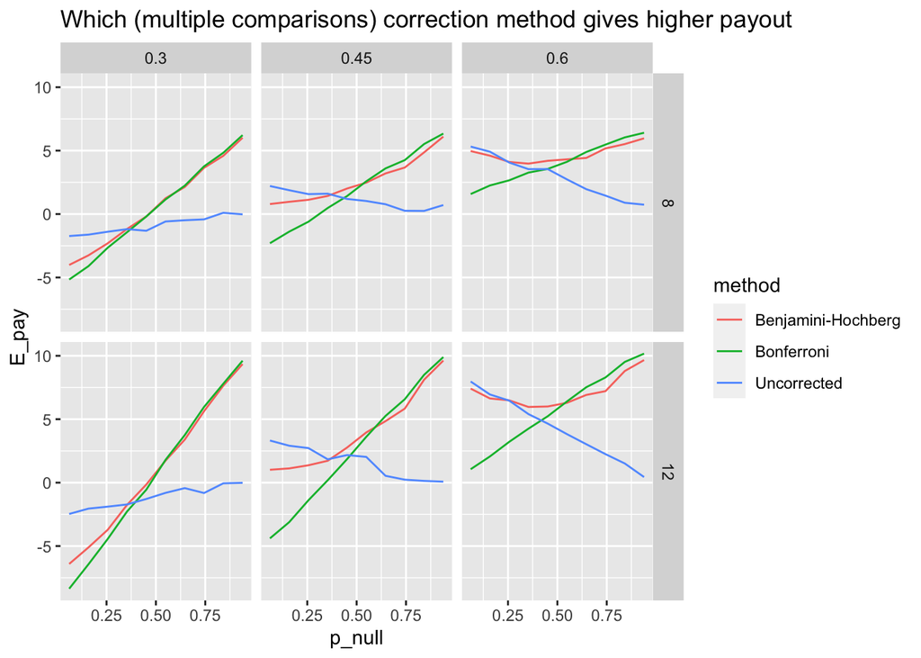

Checking the incentives: we pllot the $\alpha$ value where payout is the highest, and see how close it is to 0.05 under different strategies.

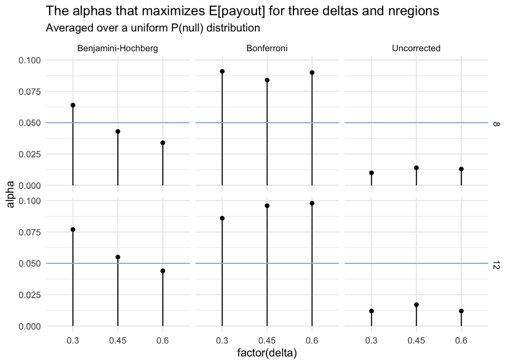

### Other explorations

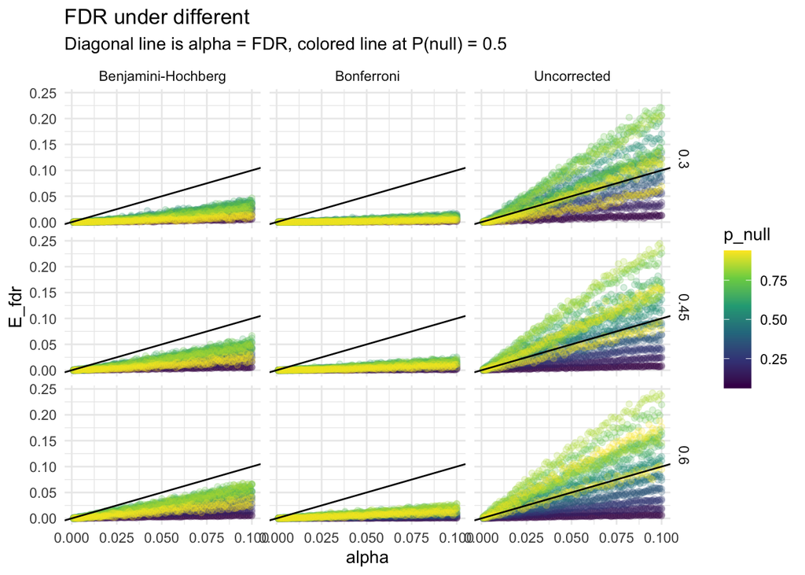

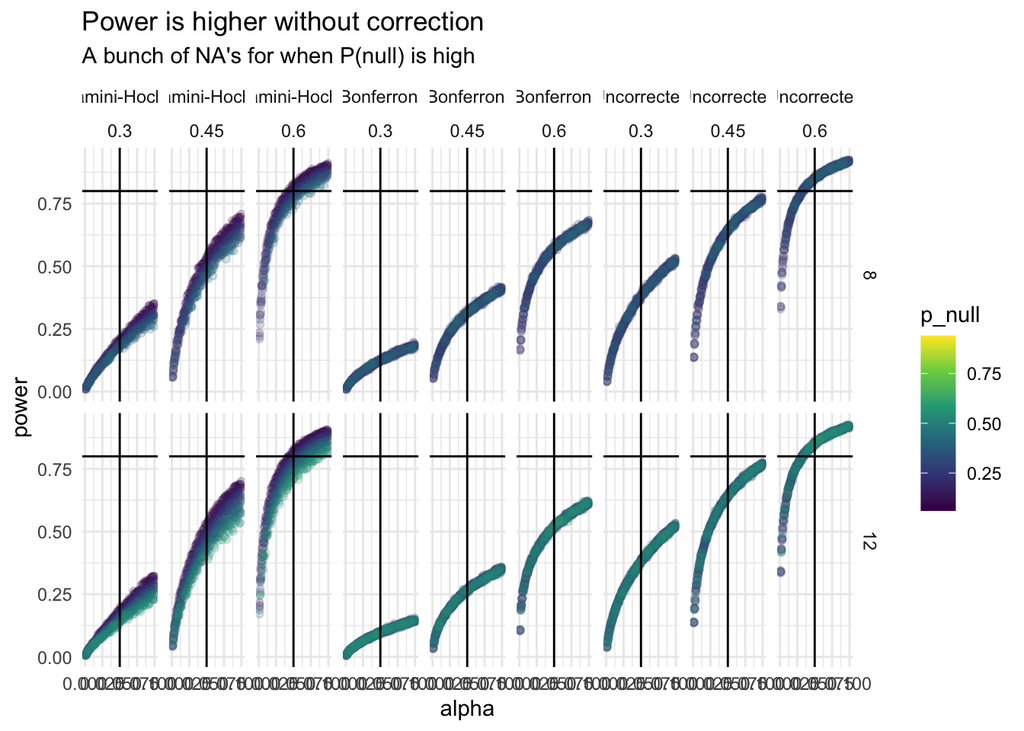

## Comparing stimuli data to alternative datasets drawn from the same data generating process

For Section 5.3 Limitations

```
## # A tibble: 700 x 7
##    nregions trial  mean    sd    mu data       delta
##       <dbl> <int> <dbl> <dbl> <dbl> <list>     <dbl>
##  1       12     1   0.9     3   0   <dbl [20]>   0.3
##  2       12     1   0.9     3   0   <dbl [20]>   0.3
##  3       12     1   0.9     3   0.9 <dbl [20]>   0.3
##  4       12     1   0.9     3   0   <dbl [20]>   0.3
##  5       12     1   0.9     3   0   <dbl [20]>   0.3
##  6       12     1   0.9     3   0   <dbl [20]>   0.3
##  7       12     1   0.9     3   0.9 <dbl [20]>   0.3
##  8       12     1   0.9     3   0   <dbl [20]>   0.3
##  9       12     1   0.9     3   0.9 <dbl [20]>   0.3
## 10       12     1   0.9     3   0   <dbl [20]>   0.3
## # … with 690 more rows
```

Table of confusion matrix categories from stimuli data, under two strategies

```
##   alpha nregions             method trial       tp         fp       tn       fn
## 1  0.05        8 Benjamini-Hochberg    18 1.628571 0.14285714 3.828571 2.400000
## 2  0.05        8        Uncorrected    18 2.685714 0.40000000 3.571429 1.342857
## 3  0.05       12 Benjamini-Hochberg    18 2.628571 0.08571429 5.800000 3.485714
## 4  0.05       12        Uncorrected    18 3.942857 0.25714286 5.628571 2.171429
##          fdr     power
## 1 0.03530612       NaN
## 2 0.09340136       NaN
## 3 0.01642857 0.4503515
## 4 0.03214286 0.6546599
```

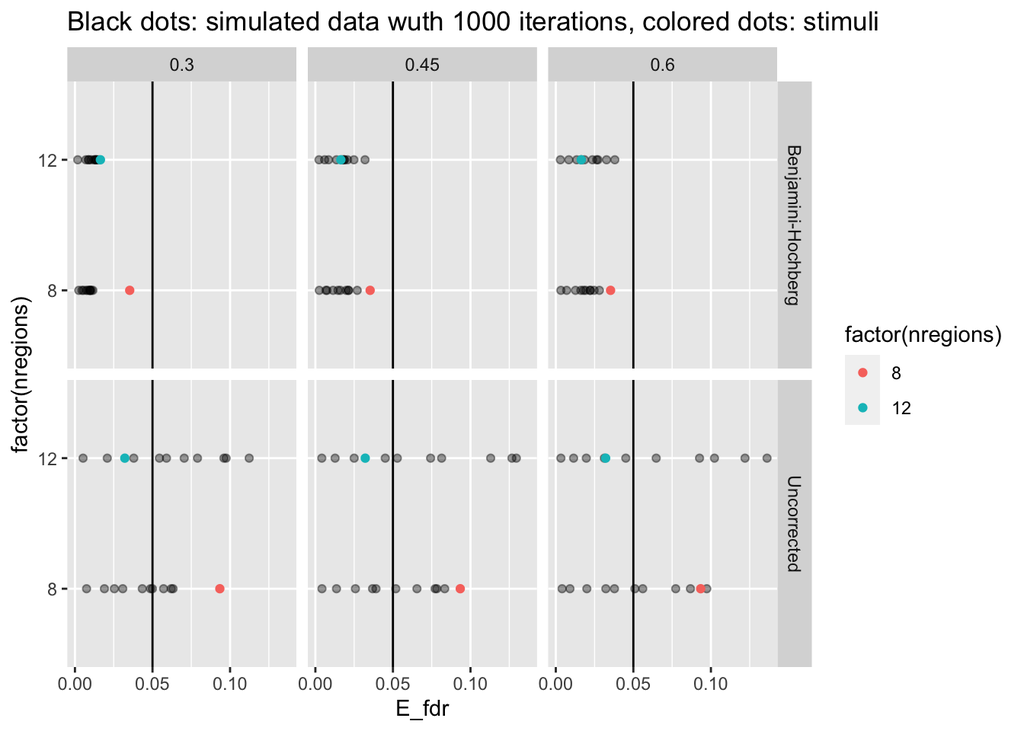